# Hidden Markov Models and Bayesian MARSS models

Eli Holmes, Eric Ward

17 February 2021

# Part 1. Hidden Markov Models

## Data

First, let’s grab the data.

```r
library(dplyr)
#install.packages("rsoi")
pdo <- rsoi::download_pdo()
```

We will look at the winter PDO only. We need to shift the year for Oct-Dec by +1 since Oct-Feb spans 2 calendar years. Then we need to remove the first year since that would only have Jan-Feb.

```r
pdo$Year[which(pdo$Month%in%c("Oct","Nov","Dec"))] <- pdo$Year[which(pdo$Month%in%c("Oct","Nov","Dec"))] + 1
pdo <- dplyr::group_by(pdo, Year) %>%
  dplyr::summarize(winter_pdo = mean(PDO[which(Month %in% c("Oct","Nov","Dec","Jan","Feb"))])) %>%
  dplyr::select(winter_pdo, Year)
# The first year will be missing Oct-Dec
pdo <- pdo[-1,]
```

Use the `depmixS4` package discussed in the [HMM lecture](https://atsa-es.github.io/atsa/Lectures/Week%205/lec_10_hmm.html#1) to answer the questions in in Part 1.

## Q1

1. Fit a 2-state HMM to the annual indices of winter PDO. Assume Gaussian errors (default).

```r
library("depmixS4")
mod <- depmix(response = winter_pdo ~ 1, data = pdo, nstates = 2, trstart = runif(4))
fitmod <- fit(mod)
```

```
## converged at iteration 25 with logLik: -142.8743
```

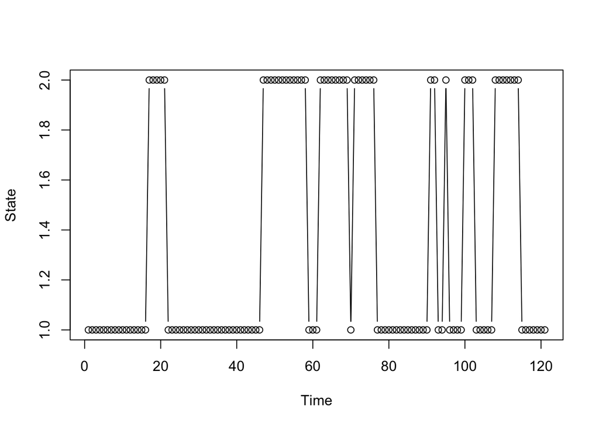

```r
prstates <- apply(posterior(fitmod)[,c("S1","S2")],
  1, which.max)
plot(prstates, type="b", xlab="Time", ylab="State")
```

## Q2

2. Try fitting the model 10-20 times. Does the likelihood seem reasonably stable? (Note `logLik()` gets you the log-likelihood from model fits in R).

```r
ll <- rep(NA,20)
for(i in 1:20){
mod <- depmix(response = winter_pdo ~ 1, data = pdo, nstates = 2)
fitmod <- fit(mod)
ll[i] <- logLik(fitmod)
}
```

Looks good.

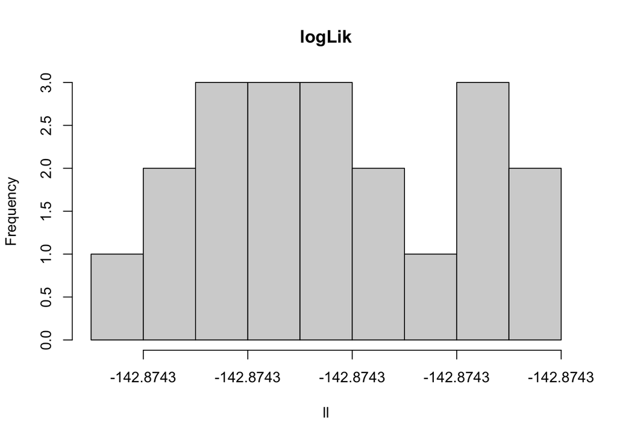

```r
hist(ll, main="logLik")
```

## Q3

3. What is the transition matrix for the best model? What are the persistence probabilities (e.g. probabilities of staying in the same state from step $t$ to $t+1$)?

```r
summary(fitmod, which="transition")
```

```
## Transition matrix
##         toS1  toS2
## fromS1 0.848 0.152
## fromS2 0.116 0.884
```

Make a matrix.

```r
GAM <- matrix(getpars(fitmod)[3:6],2,2, byrow=TRUE)
GAM
```

```
##           [,1]      [,2]
## [1,] 0.8483073 0.1516927
## [2,] 0.1163817 0.8836183
```

Persistence probabilites are 0.8483073 for staying in state 1 andd 0.8836183 for staying state 2.

## Q4

4. Using slide 15 of the HMM lecture as a template and the matrix in Q3, write out your fitted HMM model as equations.

$$P[x_{t+1}=j|x_t=i] = \gamma_{i,j}$$

The $\gamma_{i,j}$ matrix is $\Gamma$, where the rows are *from* so $i$ and the columns are *to* so $j$. So looks just like the matrix in Question 3.
$$\Gamma = \begin{bmatrix}\gamma_{1,1}&\gamma_{1,2}\\
\gamma_{2,1}&\gamma_{2,2}\end{bmatrix} = \begin{bmatrix}0.848&0.152\\0.116&0.884\end{bmatrix}$$

## Q5

5. Plot the predicted values versus year. See slide 50 of the HMM lecture for an example.

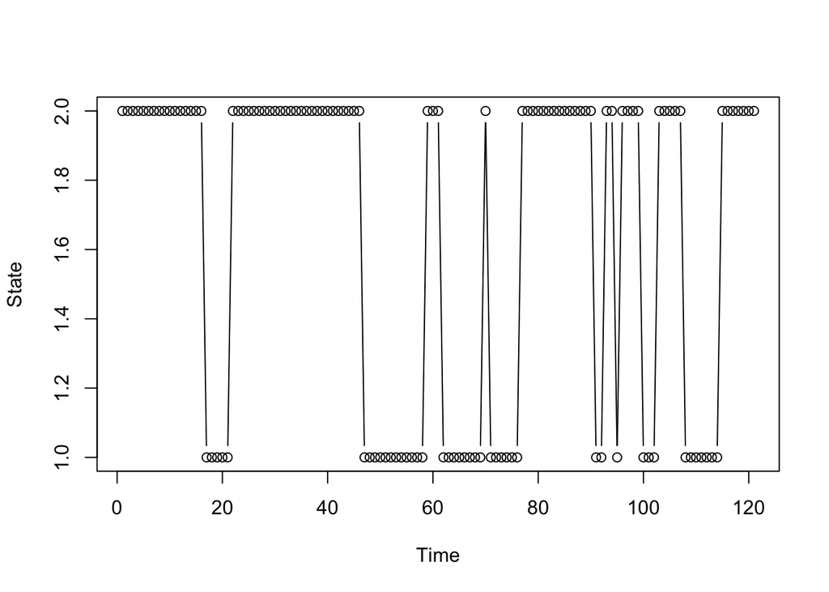

```r
prstates = apply(posterior(fitmod)[,c("S1","S2")],
  1, which.max)
plot(prstates, type="b", xlab="Time", ylab="State")
```

## Q6

6. Plot the posterior probability of being in the various states from your best model (e.g. probability of being in state 1 over time)

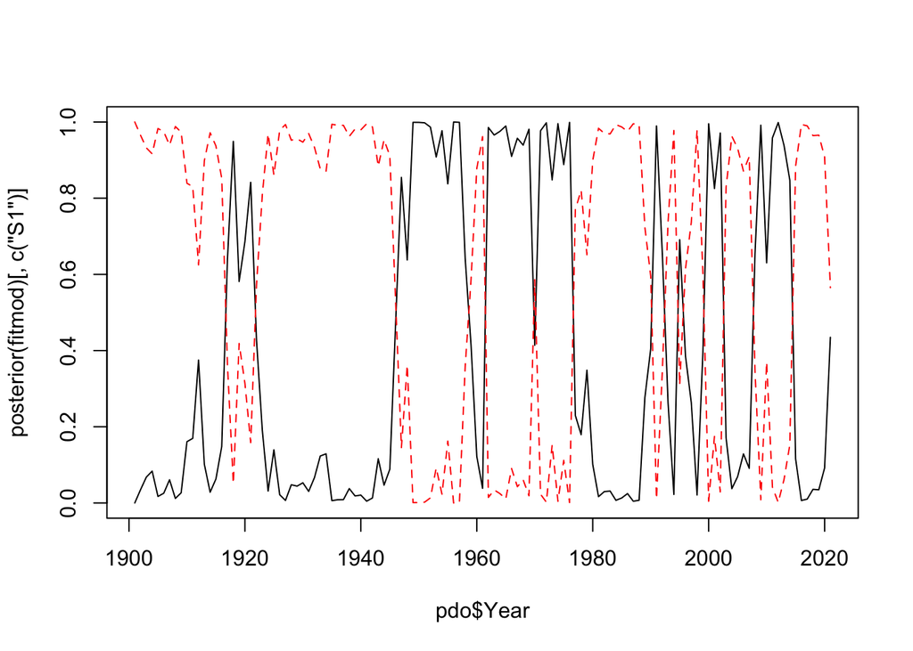

```r
plot(pdo$Year, posterior(fitmod)[,c("S1")], type="l")
lines(pdo$Year, posterior(fitmod)[,c("S2")], col="red", lty=2)
```

## Q7

7. What is the long-run probability that the PDO is in state 1 versus state 2? You can calculate this from the transition matrix. There is an analytical solution for this (a bit of googling will find it). Or you can run a `for` loop to find it. Let $p_1$ be the probability that PDO is in state 1 and $p_2$ be the probability that PDO is in state 2. Note $p_1 + p_2 = 1$. If $P$ is the transition matrix (in Q3),

$$\begin{bmatrix}p_1&p_2\end{bmatrix}_n = \begin{bmatrix}p_1&p_2\end{bmatrix}_{n-1} P$$
Note this is a 1x2 matrix times a 2x2 matrix on the right. Start with $p_1=1$ and $p_2=0$, say. Run a `for` loop until

$$\begin{bmatrix}p_1&p_2\end{bmatrix}_n \approx \begin{bmatrix}p_1&p_2\end{bmatrix}_{n-1}$$

```r
x.stationary <- matrix(c(0,1), 1, 2)
for(i in 1:1000) x.stationary <- x.stationary %*% GAM
x.stationary
```

```
##           [,1]      [,2]
## [1,] 0.4341395 0.5658605
```

So about 43.4% of the time, the PDO will be in state 1.

To get the analytical solution, find the stationary distribution of a Markov chain. Watch [this youtube video](https://www.youtube.com/watch?v=j93286JaPY8) for example. You solve this linear equation:
$$\begin{bmatrix}p_1\\p_2\end{bmatrix} = P^\top \begin{bmatrix}p_1\\p_2\end{bmatrix}$$
with the constraint that $p_1 + p_2 = 1$. One of the constraints from our transition equation is extra, so we remove that. That’s the `-1` in the code.

```r
b <- matrix(c(0,1), ncol=1)
A <- rbind(t(GAM)-diag(1,2), 1)
solve(A[-1,], b)
```

```
##           [,1]
## [1,] 0.4341395
## [2,] 0.5658605
```

## Optional Analyses

- Change the model to a 1-state, 3-state model and a 4-state model. Using AIC as a model selection metric, which model performs better (lower AIC): 1, 2, 3, or 4 state?

2-state is best via AIC.

```r
df <- data.frame(model=paste("State", 1:4), AIC=NA)
for(i in 1:4){
mod <- depmix(response = winter_pdo ~ 1, data = pdo, nstates = i)
fit <- fit(mod)
df$AIC[i] <- AIC(fit)
}
```

```r
knitr::kable(df)
```

| model | AIC |
| --- | --- |
| State 1 | 315.9630 |
| State 2 | 299.7486 |
| State 3 | 304.7102 |
| State 4 | 317.3225 |

- Compare the transition matrices for fits with different random starting conditions. Are the transition matrices stable?

Looks quite stable.

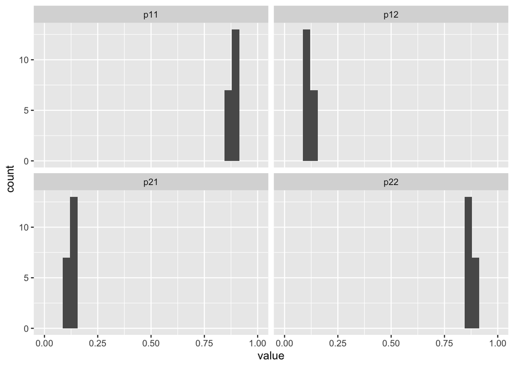

```r
pars <- c()
for(i in 1:20){
mod <- depmix(response = winter_pdo ~ 1, data = pdo, nstates = 2)
fitmod <- fit(mod)
pars <- rbind(pars, data.frame(name=c("p11", "p12", "p21", "p22"), value=getpars(fitmod)[3:6]))
}
library(ggplot2)
ggplot(pars, aes(x=value)) + geom_histogram() + xlim(c(0,1)) + facet_wrap(~name)
```

- Run diagnostics on the best model. Any problems?

```r
mod <- depmix(response = winter_pdo ~ 1, data = pdo, nstates = 2, trstart = runif(4))
fitmod <- fit(mod)
```

Hmm, `depmixS4` does not appear to return the pseudo-residuals for HMMs.

- If you include time varying parameters (e.g. year) in the means of each state, or state transition probabilities, does the model do any better?

Let’s include year in the response model.

```r
library("depmixS4")
mod <- depmix(
  response = winter_pdo ~ 1 + Year,
  data = pdo, nstates = 2, trstart = runif(4))
fitmod <- fit(mod)
```

```
## converged at iteration 53 with logLik: -138.3141
```

This model has higher log likelihood and lower AIC.

```r
logLik(fitmod)
```

```
## 'log Lik.' -138.3141 (df=9)
```

```r
AIC(fitmod)
```

```
## [1] 294.6282
```

Let’s include year in the transition model. This one is not better.

```r
library("depmixS4")
mod <- depmix(
  response = winter_pdo ~ 1,
  transition = ~ 1 + Year,
  data = pdo, nstates = 2,
  pstart = runif(4))
fitmod <- fit(mod)
```

```
## converged at iteration 72 with logLik: -141.0019
```

```r
logLik(fitmod)
```

```
## 'log Lik.' -141.0019 (df=9)
```

```r
AIC(fitmod)
```

```
## [1] 300.0038
```